# Visual Assessment Of Clustering Tendency for Finding Number of Clusters in a Dataset

Zeynel Cebeci

December 13, 2019

**`VatAna` is an R package implements the *Visual Assessment of Cluster Tendency (VAT)* algorithm proposed by Bezdek & Hathaway (2002).**

To cite this vignette and package ‘VatAna’, please use one of the following items that fits to your references list:

Cebeci, Z. & Yildiz, F. (2015). Görsel Kümelenme Eğilimi Değerlendirmesi ve R’de Uygulaması. *Çukurova Üniversitesi Ziraat Fakültesi Dergisi*, Vol. 30, no. 2, pp. 1-8. (URL: https://dergipark.org.tr/en/download/article-file/219860)

or in BibTeX format:

```
@article{cebeci30gorsel,
  title={G{\"o}rsel K{\"u}melenme E{\u{g}}ilimi De{\u{g}}erlendirmesi ve R’de Uygulamas{\i}},
  author={Cebeci, Zeynel and Yildiz, Figen},
  journal={{\c{C}}ukurova {\"U}niversitesi Ziraat Fak{\"u}ltesi Dergisi},
  volume={30},
  number={2},
  pages={1--8}
}
```

# 1 Dataset and Packages

## 1.1 Install and load the package VatAna

In order to install the package `VatAna` from the GitHub repository you should first install the `devtools` package from CRAN into your local system. Then you can install the package `VatAna` using `install_github` of `devtools` package as shown with the R code chunks below:

```r
if(!require(devtools)) {install.packages('devtools'); library(devtools)}
install_github("zcebeci/VatAna")
```

If you would like to have a compiled version of the vignettes of the package try to install the package `VatAna` using `install_github` with `build_vignettes` argument set to TRUE as shown below:

```r
if(!require(devtools)) {install.packages('devtools'); library(devtools)}
 devtools::install_github("zcebeci/VatAna", build_vignettes=TRUE)
```

If you have not already installed `rmarkdown` and `prettydoc` in your local system, before running the above install commands firstly install these packages as following:

```r
install.packages('prettydoc')
```

If you have already installed ‘`VatAna`’, you can load it into R working environment by using the following command:

```r
library(VatAna)
```

## 1.2 Load the data set

We demonstrate clusterig validation using the package ‘`VatAna`’ on the dataset `protcarbo` consisting of two features (`energy` and `protein`) of 15 human food.

```r
data(protcarbo)
print(protcarbo)
```

```
   energy protein
1      75      12
2     340      20
3     165      17
4     355      19
5      70      11
6     182      17
7      65      10
8     173      16
9     185      17
10    155      16
11    340      19
12     90      11
13    180      17
14    375      19
15    145      16
```

The following R command displays the scatter plots between the feature pairs.

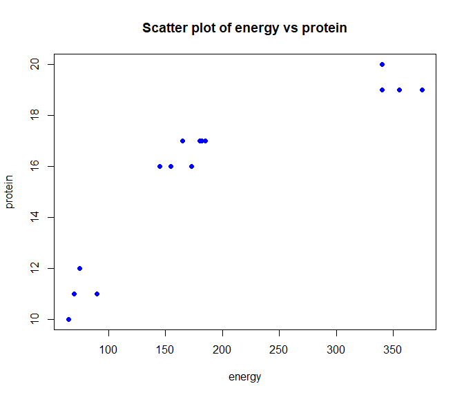

```r
plot(protcarbo, pch=19, col=4, main="Scatter plot of energy vs protein")
```

# 2 Building the dissimilarities matrices

The function `vatimage` in the package generates the original dissimilarities matrix (DM) and the reordered dissimilarities matrix (ODM) as follows. If the argument `disp` is set to `TRUE`, the matrix ODM is displayed as an image (ODI).

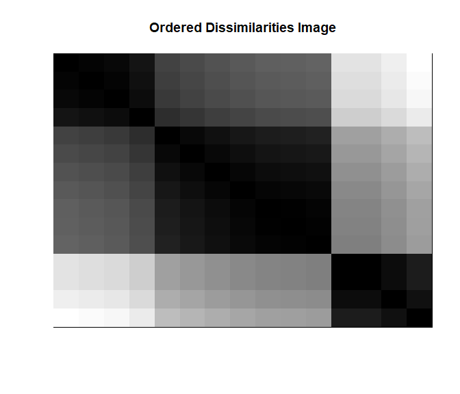

```r
resimg <- vatimage(protcarbo, disp=TRUE)
```

Above the result of `vatimage` run was assigned to `resimg` object to use by forthcoming analyses. The original dissimilarities matrix (DM) is extracted from `resimg` and stored in `dm` and then its first 3 rows are displayed for giving an idea about its content.

```r
dm <- resimg$dm
head(dm, 3)
```

```
          1        2         3        4         5        6         7
1   0.00000 265.1207  90.13878 280.0875   5.09902 107.1168  10.19804
2 265.12073   0.0000 175.02571  15.0333 270.14996 158.0285 275.18176
3  90.13878 175.0257   0.00000 190.0105  95.18929  17.0000 100.24470
           8        9        10       11        12       13        14
1  98.081599 110.1136  80.09994 265.0924  15.03330 105.1190 300.08166
2 167.047897 155.0290 185.04324   1.0000 250.16195 160.0281  35.01428
3   8.062258  20.0000  10.04988 175.0114  75.23962  15.0000 210.00952
         15
1  70.11419
2 195.04102
3  20.02498
```

In the following code chunk, the reordered dissimilarities matrix (ODM) is built from the `vatimage` run above, and its first 3 rows are displayed for giving an idea about its content.

```r
odm <- resimg$odm
head(odm, 3)
```

```
        14        4        2       11        9        6       13        8
7 310.1306 290.1396 275.1818 275.1472 120.2040 117.2092 115.2128 108.1665
5 305.1049 285.1123 270.1500 270.1185 115.1564 112.1606 110.1635 103.1213
1 300.0817 280.0875 265.1207 265.0924 110.1136 107.1168 105.1190  98.0816
          3       10       15       12        1       5        7
7 100.24470 90.19978 80.22468 25.01999 10.19804 5.09902  0.00000
5  95.18929 85.14693 75.16648 20.00000  5.09902 0.00000  5.09902
1  90.13878 80.09994 70.11419 15.03330  0.00000 5.09902 10.19804
```

# 3 Displaying the dissimilarities matrices

The function `vatdisp` of the package displays the original dissimilarities matrix (DM) and the reordered dissimilarities matrix (ODM) and the binary reordered dissimilarities matrix (BDM).

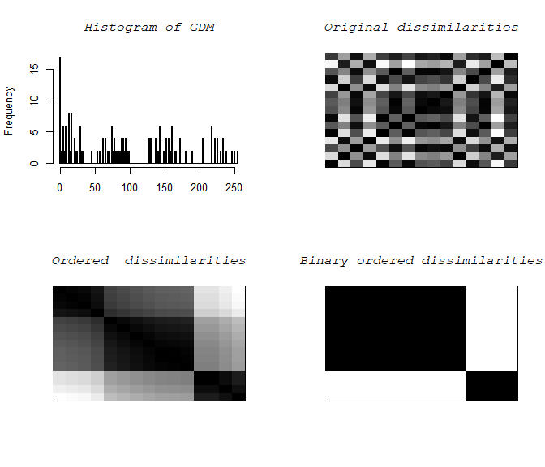

```r
vatdisp(protcarbo)
```

The default color palette is `"grey"` for the images displayed by `vatdisp`. But users can assign one of following items to the argument `renk` for changing the color palette.

| renk | Used color palette |
| --- | --- |
| `cm` | cm.colors |
| `grey` | gray256 colors |
| `heat` | heat.colors |
| `terrain` | terrain.colors |
| `topo` | topo.colors |

In the following code chunk, `vatdisp` displays the images by using `terrain.colors()` palette.

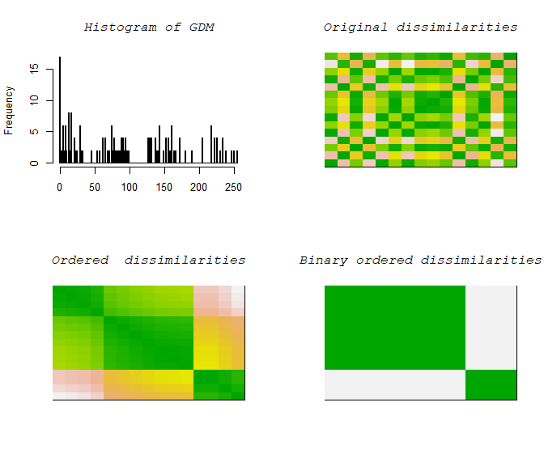

```r
vatdisp(protcarbo, renk="terrain")
```

One of the images in the figure above can also be displayed as an alone image as shown for the ODM matrix in the following code chunk.

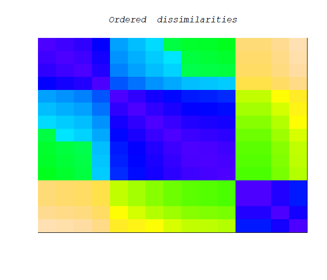

```r
vatdisp(protcarbo, renk="topo", which=3)
```

Binary images are produced with the Otsu Thresholding method.

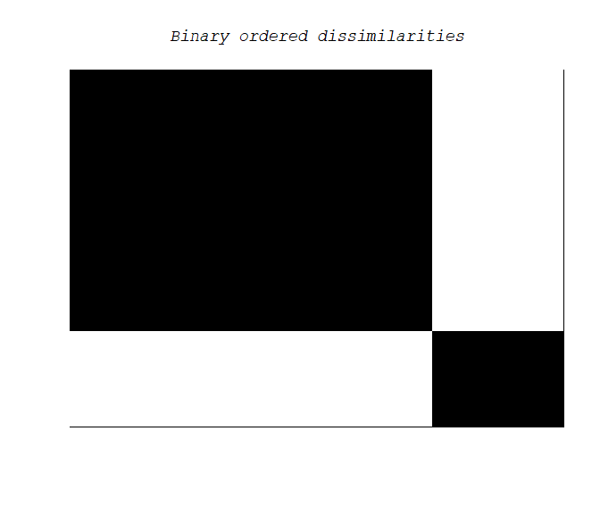

```r
vatdisp(protcarbo, renk="grey", which=4)
```

# 4 Greyscale and Binary images

## 4.1 Greyscale images

In following code chunk, the greyscale image is generated with 256 grey-levels as usual.

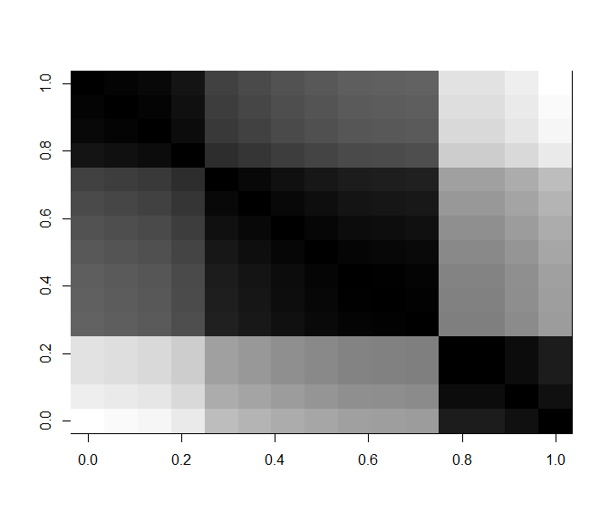

```r
godm <- greyimage(odm, greylevel=256, disp=TRUE)
```

In following code chunk, the greyscale image is generated with 16 grey-levels.

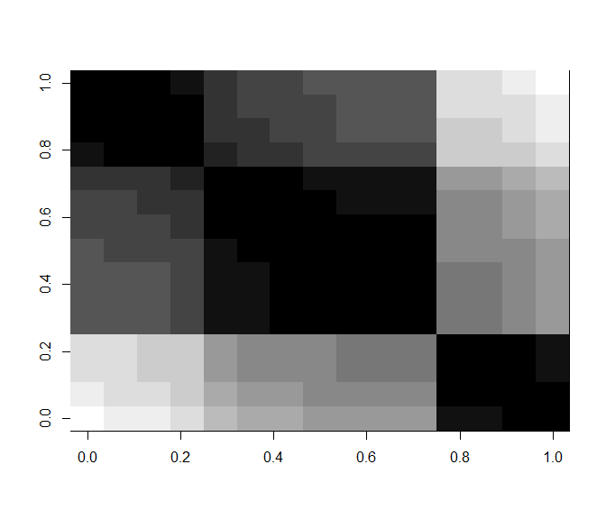

```r
godm2 <- greyimage(odm, greylevel=16, disp=TRUE)
```

## 4.2 Binary images

A binary image is generated by the function `binimage` using a greyscale image which is output of the function `greyscale`. There are several methods for avaliable to build binary images are listed in the package manual. In the following code chunk, the binary image displayed is produced with Otsu thresholding method.

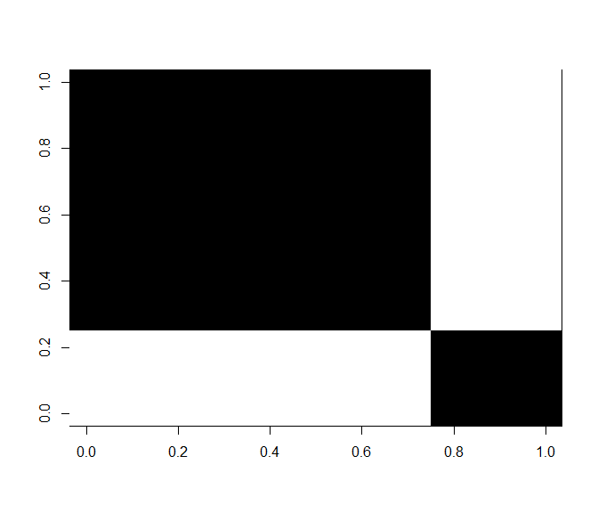

```r
bodm1 <- binimage(godm, method="otsu", disp=TRUE)
```

In the following code chunk, the binary image is produced with the `auto` option using an automatic thresholding value which is calculated from the processed ODM.

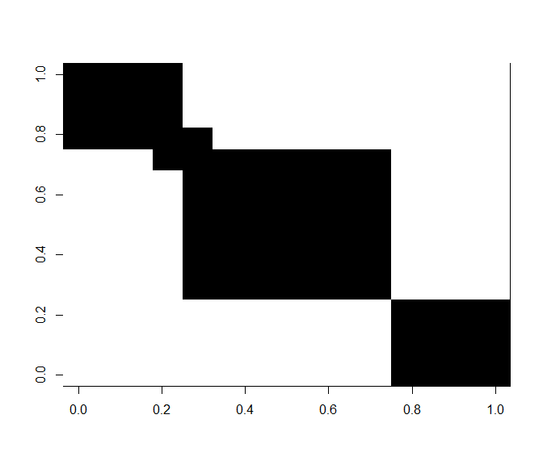

```r
bodm2 <- binimage(godm, method="auto", disp=TRUE)
```

In the following code chunk, the binary image is produced with a fixed `t`, a user-defined threshold value.

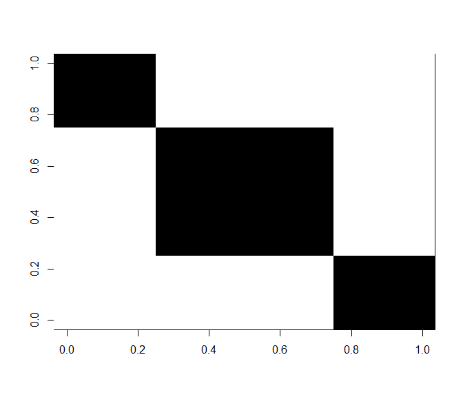

```r
bodm3 <- binimage(godm, method="fixed", t=40, disp=TRUE)
```

# 5 Finding the number of clusters in a dataset

The package `VatAna` has two functions to propose a number of clusters for a given dataset. They work with the different techniques to count the blocks in binary dissimilarities matrices.

## 5.1 Finding Number Clusters - Method I

The function `findk` finds the number of clusters by tracing the horizontal and vertical borders of the blocks in ODIs. In this way overlapped and well-separated blocks are counted, and the count is proposed as the number of clusters in the dataset. In the following code chunk, the ODM matrix called as `pcodm` is used as the input argument in the call of `findk`, and the computed `k` is returned and displayed.

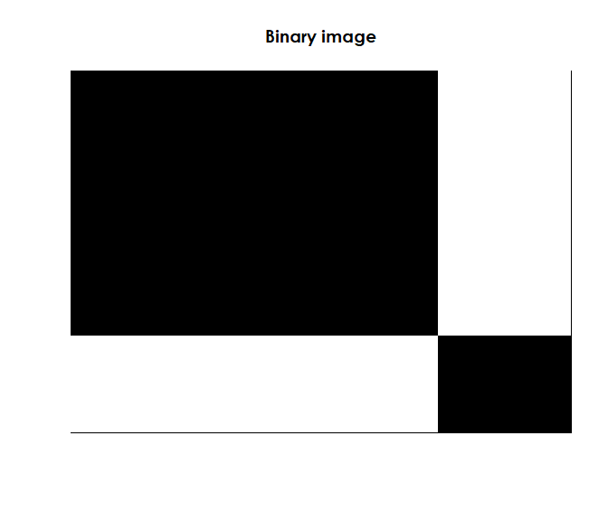

```r
resimg <- vatimage(protcarbo, disp=FALSE)
pcodm <- resimg$odm
pcgdm <- greyimage(pcodm)
pcbdm <- binimage(pcgdm, method="otsu")$binimg
k <- findk(pcbdm, disp=TRUE)$k
```

```r
cat("Proposed number of clusters:", k, "\n")
```

```
Proposed number of clusters: 2
```

## 5.2 Finding Number Clusters - Method II

The function `findk2` finds the number of clusters by tracing only along the diagonal of the blocks in ODIs. In this way only the well-separated blocks can be counted. The count is proposed as the number of clusters in the dataset. With the function `findk2` in following code chunk, `pcodm`, the ordered dissimilarities matrix is traced along its diagonal. The count of blocks is proposed as the number of clusters in the dataset`protcarbo`.

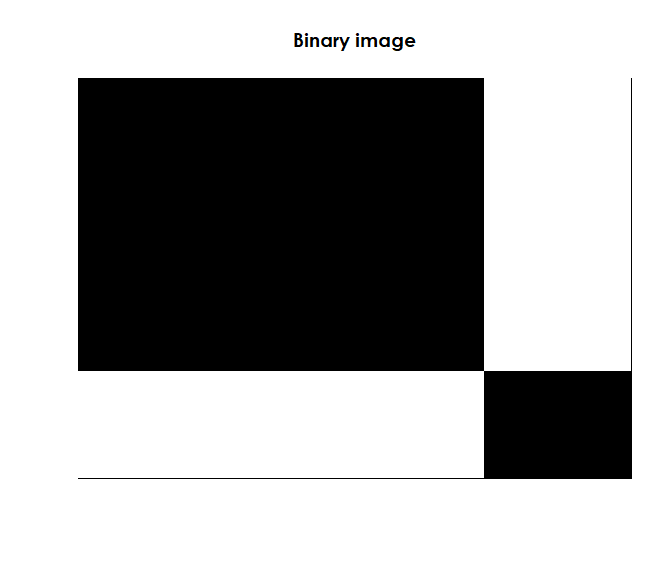

```r
resimg <- vatimage(protcarbo, disp=FALSE)
pcodm <- resimg$odm
pcgdm <- greyimage(pcodm)
pcbdm <- binimage(pcgdm)$binimg
k <- findk2(pcbdm, disp=TRUE)
```

```r
print(k)
```

```
[1] 2
```

# 6 Generate binary images

Binary images generated with known number of blocks can be used for testing the performances of block counting algorithms. In the following code chunk a binary image is generated with 6 blocks and processed by the function `findk` and `findk2`, respectively.

```r
bdm1 <- genbinimg(nb=6, seed=4, disp=TRUE)$binimg
```

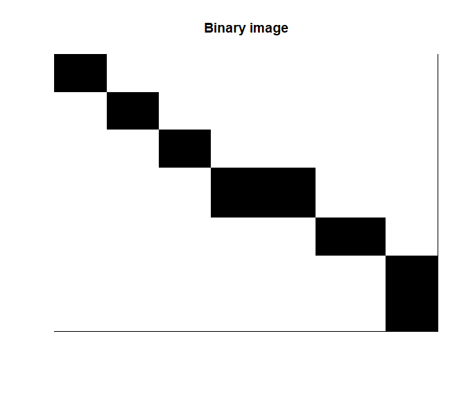

```r
k <- findk(bdm1, disp=FALSE)$k
print(k)
```

```
[1] 6
```

Since the `findk2` traces the binary image through its diagonal only it fails to find the blocks located outside diagonal. So it is recommended that to use the function `findk` for detecting the blocks more successfully.

```r
k <- findk2(bdm1, disp=FALSE)
print(k)
```

```
[1] 4
```

On the other hand, if the blocks are exactly positioned along the diagonal of binary image, both the functions will give the same result as shown below.

The output from the function `findk` for the binary image has 4 blocks along its diagonal:

```r
bdm2 <- genbinimg(nb=4, seed=65, disp=TRUE)$binimg
```

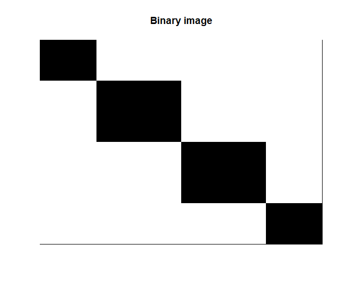

```r
k <- findk(bdm2, disp=FALSE)$k
print(k)
```

```
[1] 4
```

The output from the function `findk2` for the binary image has 4 blocks along its diagonal:

```r
k <- findk2(bdm2, disp=FALSE)
print(k)
```

```
[1] 4
```

# 7 References

Bezdek, J. C., & Hathaway, R. J. (2002). VAT: A tool for visual assessment of (cluster) tendency. In *Proceedings of the 2002 International Joint Conference on Neural Networks*. IJCNN’02 (Cat. No. 02CH37290), Vol. 3, pp. 2225-2230. IEEE.

Cebeci, Z. & Yildiz, F. (2015). Görsel Kümelenme Eğilimi Değerlendirmesi ve R’de Uygulaması. *Çukurova Üniversitesi Ziraat Fakültesi Dergisi*, 30 (2), 1-8. (URL: https://dergipark.org.tr/en/download/article-file/219860)